# Multi-seed offline comparison — BC vs CQL (answers Max Q2)

- **BC** — the BC package trainer at its full budget (390 epochs), `[Kp,Ki,Kd]` box, trained on the 4 original sunny days + the cloudy day.
- **CQL** — the `CQL_CIRL.ipynb` offline pipeline in the original `[Kp,Ki,Kw]` box: buffer pre-filled from that seed's raw BC actor (noise 0.05) over the 5 original days, then 100 × 242 CQL-H updates (the realised budget of the original run), best checkpoint by the cloudy-×3 proxy MAE.

Every seed's BC and CQL actor is evaluated **zero-shot on Juan's 4 new days** with the same rollout code as the comparison notebook. Below: the summary table, the mean ± std bars, and **4 tracking charts (one per seed), each with 4 sub-charts (one per Juan day)**.

Run `python run_multiseed.py` first (several hours; it resumes, and saves per-seed actors to `policies/`) to (re)generate `results.json` + `traces.npz`.

```python
# ── Summary: per-seed per-day MAEs on Juan's 4 days ──────────────────────────
import json, os
import numpy as np, matplotlib.pyplot as plt

res    = json.load(open("results.json"))
traces = np.load("traces.npz")
days   = [d[:11] for d in res["days"]]
seeds  = sorted(res["bc"].keys(), key=lambda s: s != "42")   # seed 42 (the replication) first

print(f"{'method':7s}{'seed':>5s}  " + "".join(f"{d:>13s}" for d in days) + f"{'mean':>9s}")
print("-" * (12 + 13 * len(days) + 9))
print(f"{'Expert':7s}{'':>5s}  " + "".join(f"{m:>13.3f}" for m in res["expert"]["per_day"])
      + f"{res['expert']['mean']:>9.3f}")
for m in ["bc", "cql"]:
    for s in seeds:
        r = res[m][s]
        print(f"{m.upper():7s}{s:>5s}  " + "".join(f"{x:>13.3f}" for x in r["per_day"])
              + f"{r['mean']:>9.3f}")

bc = np.array([res["bc"][s]["mean"]  for s in seeds])
cq = np.array([res["cql"][s]["mean"] for s in seeds])
print(f"\nBC   MAE = {bc.mean():.3f} +/- {bc.std():.3f}   vals={[round(float(x),3) for x in bc]}")
print(f"CQL  MAE = {cq.mean():.3f} +/- {cq.std():.3f}   vals={[round(float(x),3) for x in cq]}")
print(f"(seed 42 replicates BC_vs_CQL_Offline_Policy_Comparison.ipynb: BC 1.224 / CQL 0.243)")
```

```
method  seed    16_06_2026_  17_06_2026_  18_06_2026_  19_06_2026_     mean
-------------------------------------------------------------------------
Expert                1.286        1.482        1.796        0.331    1.224
BC        42          1.286        1.482        1.796        0.331    1.224
BC        36          1.286        1.482        1.796        0.331    1.224
BC        27          1.286        1.482        1.796        0.331    1.224
BC        21          1.286        1.482        1.796        0.331    1.224
CQL       42          0.255        0.272        0.378        0.050    0.239
CQL       36          0.260        0.277        0.384        0.051    0.243
CQL       27          0.261        0.283        0.404        0.053    0.250
CQL       21          0.261        0.275        0.386        0.051    0.243

BC   MAE = 1.224 +/- 0.000   vals=[1.224, 1.224, 1.224, 1.224]
CQL  MAE = 0.244 +/- 0.004   vals=[0.239, 0.243, 0.25, 0.243]
(seed 42 replicates BC_vs_CQL_Offline_Policy_Comparison.ipynb: BC 1.224 / CQL 0.243)
```

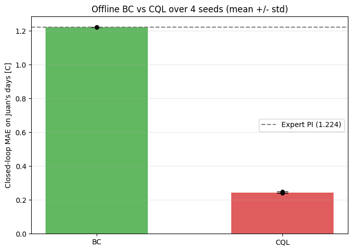

```python
# ── Mean +/- std over seeds (Juan days, zero-shot) ───────────────────────────
exp_m = res["expert"]["mean"]
fig, ax = plt.subplots(figsize=(7, 5))
ax.bar([0, 1], [bc.mean(), cq.mean()], yerr=[bc.std(), cq.std()],
       capsize=8, color=["#2ca02c", "#d62728"], alpha=.75, width=.55)
ax.scatter([0]*len(bc), bc, color="k", zorder=3, s=25)
ax.scatter([1]*len(cq), cq, color="k", zorder=3, s=25)
ax.axhline(exp_m, ls="--", c="gray", label=f"Expert PI ({exp_m:.3f})")
ax.set_xticks([0, 1]); ax.set_xticklabels(["BC", "CQL"])
ax.set_ylabel("Closed-loop MAE on Juan's days [C]")
ax.set_title(f"Offline BC vs CQL over {len(bc)} seeds (mean +/- std)")
ax.legend(); ax.grid(axis="y", alpha=.3)
fig.tight_layout(); plt.show()
```

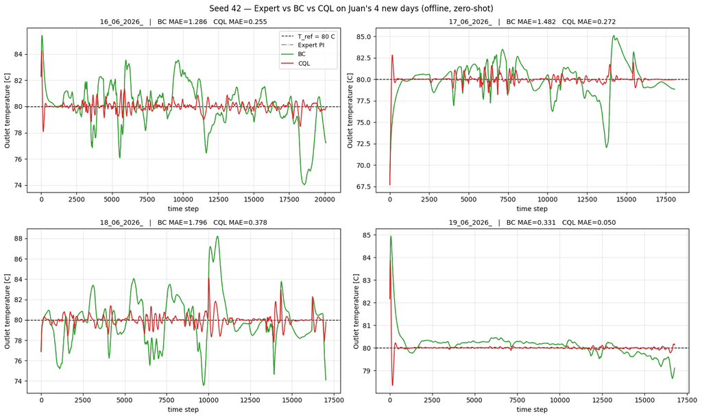

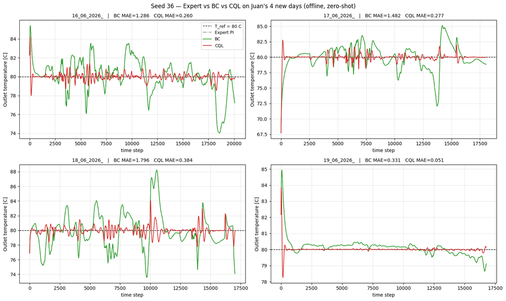

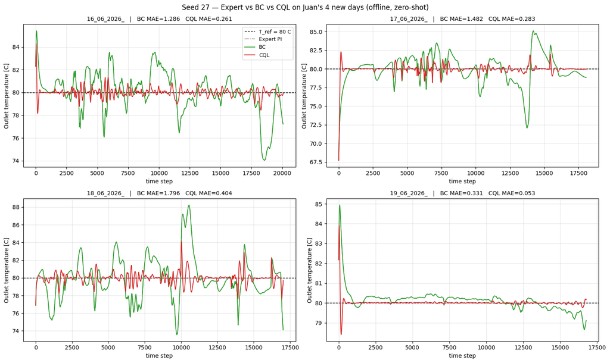

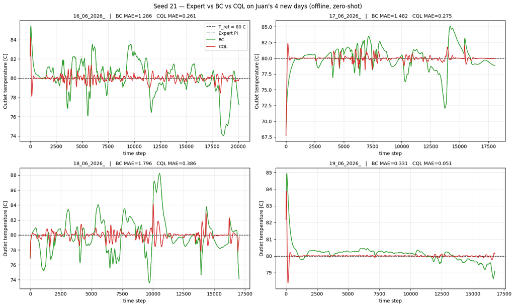

```python
# ── Tracking on Juan's 4 days: one chart per seed, 4 sub-charts (one per day) ─
TREF = 80.0                                       # Juan's days are all sunny
for s in seeds:
    fig, axes = plt.subplots(2, 2, figsize=(15, 9))
    for i, day in enumerate(days):
        ax = axes[i // 2, i % 2]
        Te = traces[f"expert_{i}"]; Tb = traces[f"bc_{s}_{i}"]; Tc = traces[f"cql_{s}_{i}"]
        t = np.arange(len(Tb))
        ax.axhline(TREF, ls="--", c="k", lw=1, label=f"T_ref = {TREF:.0f} C")
        ax.plot(t, Te[:len(t)], c="gray",    ls="-.", lw=1.2, label="Expert PI")
        ax.plot(t, Tb,          c="#2ca02c", lw=1.3,  label="BC")
        ax.plot(t, Tc,          c="#d62728", lw=1.3,  label="CQL")
        mb = res["bc"][s]["per_day"][i]; mc = res["cql"][s]["per_day"][i]
        ax.set_title(f"{day}   |   BC MAE={mb:.3f}   CQL MAE={mc:.3f}", fontsize=10)
        ax.set_ylabel("Outlet temperature [C]"); ax.set_xlabel("time step"); ax.grid(alpha=.3)
        if i == 0:
            ax.legend(fontsize=9)
    fig.suptitle(f"Seed {s} — Expert vs BC vs CQL on Juan's 4 new days (offline, zero-shot)",
                 fontsize=12)
    fig.tight_layout(); plt.show()
```

[output not shown]

[figure not shown]

```python
# ── Actions vs time step (per Max): deploy each trained policy and record the
#    action it applies at every state — gains [Kp, Ki, Kw] + the resulting flow q.
#    BC acts in the [Kp,Ki,Kd] box (Kd=0, anti-windup Kw = Ki/Kp derived);
#    CQL acts in the [Kp,Ki,Kw] box (learns the anti-windup gain directly).
KP_E, KI_E = -0.50, -0.50 / 300.0
EXP_G = {"Kp": KP_E, "Ki": KI_E, "Kw": KI_E / KP_E}
ACT_ROWS = [("Kp", "Kp  [-]"), ("Ki", "Ki  [-]"), ("Kw", "Kw  (anti-windup)  [-]"),
            ("q",  "flow q  [L/min]")]
for s in seeds:
    fig, axes = plt.subplots(2, 2, figsize=(15, 9), sharex="col")
    for j, day in enumerate(days):
        for r, (key, ylab) in enumerate(ACT_ROWS):
            ax = axes[r, j]
            Ab = traces[f"bc_{s}_{j}_{key}"]; Ac = traces[f"cql_{s}_{j}_{key}"]
            t = np.arange(len(Ab))
            if key == "q":
                Qe = traces[f"expert_{j}_q"]
                ax.plot(t, Qe[:len(t)], c="gray", ls="-.", lw=1.0, label="Expert PI")
            else:
                ax.axhline(EXP_G[key], ls="-.", c="gray", lw=1.0, label=f"Expert ({EXP_G[key]:.4f})")
            ax.plot(t, Ab, c="#2ca02c", lw=1.0, label="BC")
            ax.plot(t, Ac, c="#d62728", lw=1.0, label="CQL")
            if r == 0: ax.set_title(day, fontsize=10)
            if j == 0: ax.set_ylabel(ylab)
            if r == len(ACT_ROWS) - 1: ax.set_xlabel("time step")
            ax.grid(alpha=.3)
            if r == 0 and j == 0: ax.legend(fontsize=8)
    fig.suptitle(f"Seed {s} — actions applied at each time step on Juan's 4 new days "
                 f"(BC [Kp,Ki,Kd->Kw=Ki/Kp] vs CQL [Kp,Ki,Kw]; q = resulting flow)", fontsize=12)
    fig.tight_layout(); plt.show()
```

[output not shown]